# Mande valency

**Конструкции главное**

Здесь одно и то же расстояние по хитмэпу, кластеризации:

**heatmap**

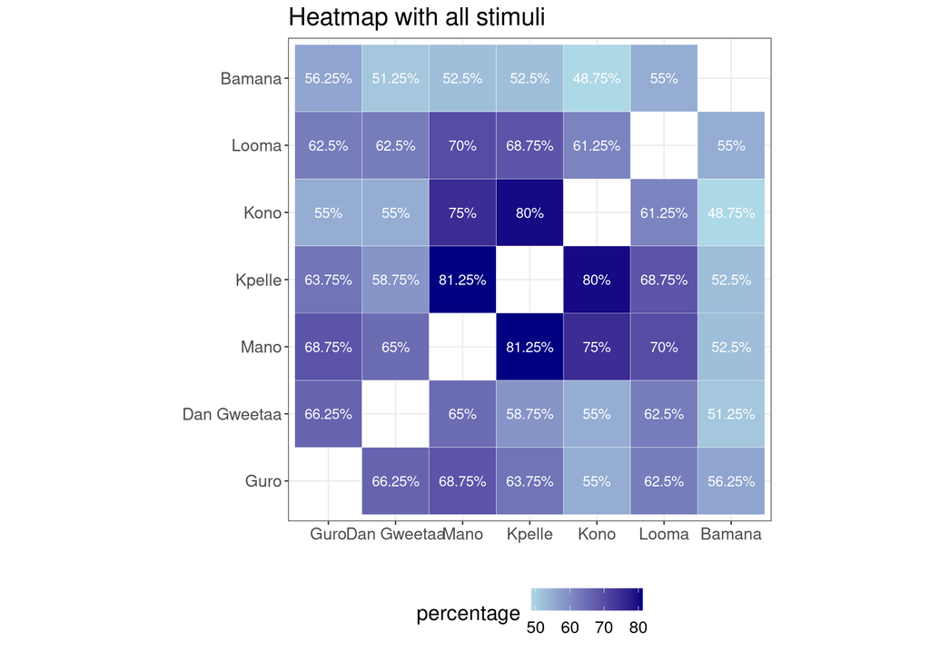

```r
df |>
  filter(number %in% to_keep,
         !str_detect(construction, "no equivalent"),
         !is.na(construction_type)) |>
  arrange(language)  |>
  distinct(language, number, construction_type)  |>
  pairwise_count(language, number) |>
  rename(total = n) ->
  df_pairwise_total

df |>
  filter(number %in% to_keep,
         !str_detect(construction, "no equivalent"),
         !is.na(construction_type)) |>
  group_by(number) |>
  arrange(language) |>
  pairwise_count(language, construction_type)  |>
  mutate(n = 1) |>
  group_by(item1, item2) |>
  reframe(n = sum(n)) ->
  df_pairwise_within_construction

df_pairwise_total |>
  left_join(df_pairwise_within_construction) |>
  mutate(percentage = round(n/total*100, 2),
         item1 = case_match(item1,
                            "Dan_Gweetaa" ~ "Dan Gweetaa",
                            .default = item1),
         item2 = case_match(item2,
                            "Dan_Gweetaa" ~ "Dan Gweetaa",
                            .default = item2)) |>
  select(item1, item2, percentage) |>
  mutate(item1 = factor(item1, levels = c("Guro", "Dan Gweetaa", "Mano", "Kpelle", "Kono", "Looma", "Bamana")),
         item2 = factor(item2, levels = c("Guro", "Dan Gweetaa", "Mano", "Kpelle", "Kono", "Looma", "Bamana"))) |>
  ggplot(aes(item1, item2))+
  geom_tile(aes(fill = percentage), colour = "white") +
  geom_text(aes(label = str_c(percentage, "%")), colour = "white") +
  scale_fill_gradient(low = "lightblue", high = "navy")+
  coord_fixed()+
  labs(x = "", y = "", title = "Heatmap with all stimuli") +
  theme(legend.position = "bottom")
```

**hclust**

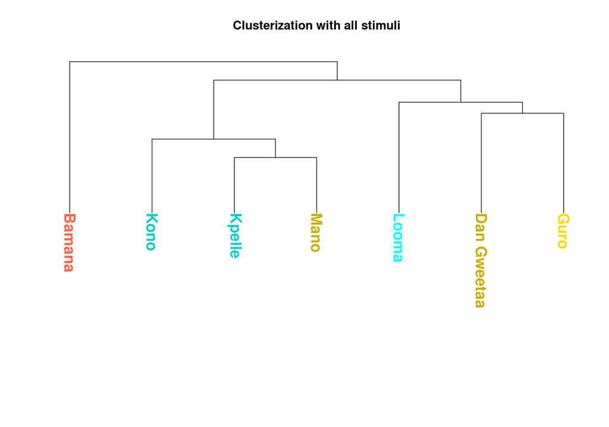

```r
df_pairwise_total |>
  left_join(df_pairwise_within_construction) |>
  mutate(percentage = 100-round(n/total*100, 2),
         item1 = case_match(item1,
                            "Dan_Gweetaa" ~ "Dan Gweetaa",
                            .default = item1),
         item2 = case_match(item2,
                            "Dan_Gweetaa" ~ "Dan Gweetaa",
                            .default = item2)) |>
  select(item1, item2, percentage) |>
  pivot_wider(names_from = item2, values_from = percentage) |>
  arrange(item1) |>
  select(-item1) |>
  as.dist() ->
  dist_gold_standard

library("ape")
dist_gold_standard |>
  hclust() |>
  as.phylo() %>%
  plot(main = "Clusterization with all stimuli",
       tip.color = colors$color[match(.$tip.label, colors$language)],
       direction = "downwards",
       cex = 1.5,
       font = 2)
```

**neighbornet**

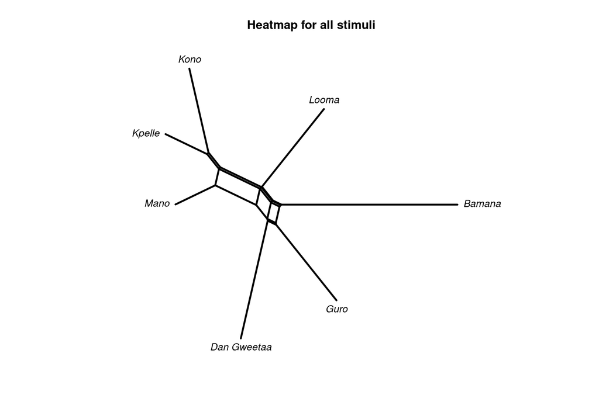

```r
dist_gold_standard |>
  neighborNet() |>
  plot()
title(main = "Heatmap for all stimuli")
```

**Конструкции**

Я вынул из таблицы данные по дан, гуро, коно, кпелле, лоома, мано и сделал столбцы

- `number`
- `cunstruction`
- `exteded_cunstruction`
- `postposition`
- `language`

Видимо, все эти примеры надо поправить. Сколько у нас наблюдений по каждому языку?

```r
df |>
  filter(!str_detect(construction, "no equivalent"),
         !is.na(construction_type)) |>
  count(language)
```

| language | n |
| --- | --- |
| Bamana | 157 |
| Dan_Gweetaa | 134 |
| Guro | 124 |
| Kono | 111 |
| Kpelle | 139 |
| Looma | 114 |
| Mano | 213 |

А пока давайте посмотрим на общую таблицу:

```r
df_wide <- readxl::read_xlsx("../GM_merged_wide.xlsx")
```

Можно посчитать, сколько раз пары языков заполняют один и тот же стимул:

```r
df |>
  filter(!str_detect(construction, "no equivalent"),
         !is.na(construction_type)) |>
  arrange(language) |>
  distinct(language, number) |>
  pairwise_count(language, number) |>
  rename(total = n) ->
  df_pairwise_total

df_pairwise_total |>
  pivot_wider(names_from = item2, values_from = total) |>
  arrange(item1)
```

| item1 | Bamana | Dan_Gweetaa | Guro | Kono | Kpelle | Looma | Mano |
| --- | --- | --- | --- | --- | --- | --- | --- |
| Bamana | NA | 108 | 105 | 109 | 114 | 106 | 118 |
| Dan_Gweetaa | 108 | NA | 94 | 98 | 105 | 95 | 107 |
| Guro | 105 | 94 | NA | 97 | 98 | 96 | 102 |
| Kono | 109 | 98 | 97 | NA | 107 | 98 | 110 |
| Kpelle | 114 | 105 | 98 | 107 | NA | 99 | 115 |
| Looma | 106 | 95 | 96 | 98 | 99 | NA | 104 |
| Mano | 118 | 107 | 102 | 110 | 115 | 104 | NA |

Можно посчитать, сколько раз пары языков заполняют одну и ту же конструкцию (т. е. совпадают в конструкции, в одном и том же стимуле):

```r
df |>
  filter(!str_detect(construction, "no equivalent"),
         !is.na(construction_type)) |>
  group_by(number) |>
  arrange(language) |>
  pairwise_count(language, construction_type) |>
  mutate(n = 1) |> # to unify
  group_by(item1, item2) |>
  reframe(n = sum(n)) ->
  df_pairwise_within_construction

df_pairwise_within_construction |>
  pivot_wider(names_from = item2, values_from = n) |>
  arrange(item1) |>
  select(item1, Dan_Gweetaa, Guro, Kono, Kpelle, Looma, Mano, Bamana)
```

| item1 | Dan_Gweetaa | Guro | Kono | Kpelle | Looma | Mano | Bamana |
| --- | --- | --- | --- | --- | --- | --- | --- |
| Bamana | 49 | 53 | 50 | 51 | 54 | 54 | NA |
| Dan_Gweetaa | NA | 61 | 50 | 54 | 56 | 63 | 49 |
| Guro | 61 | NA | 51 | 58 | 57 | 65 | 53 |
| Kono | 50 | 51 | NA | 84 | 57 | 81 | 50 |
| Kpelle | 54 | 58 | 84 | NA | 63 | 93 | 51 |
| Looma | 56 | 57 | 57 | 63 | NA | 67 | 54 |
| Mano | 63 | 65 | 81 | 93 | 67 | NA | 54 |

Мне кажется, что чтобы посчитать процент совпадений, о котором просила Маша, нужно разделить последнюю таблицу на предпоследнюю:

```r
df_pairwise_total |>
  left_join(df_pairwise_within_construction) |>
  mutate(percentage = round(n/total*100, 3)) |>
  select(item1, item2, percentage) |>
  pivot_wider(names_from = item2, values_from = percentage) |>
  arrange(item1) |>
  select(item1, Dan_Gweetaa, Guro, Kono, Kpelle, Looma, Mano, Bamana)
```

| item1 | Dan_Gweetaa | Guro | Kono | Kpelle | Looma | Mano | Bamana |
| --- | --- | --- | --- | --- | --- | --- | --- |
| Bamana | 45.370 | 50.476 | 45.872 | 44.737 | 50.943 | 45.763 | NA |
| Dan_Gweetaa | NA | 64.894 | 51.020 | 51.429 | 58.947 | 58.879 | 45.370 |
| Guro | 64.894 | NA | 52.577 | 59.184 | 59.375 | 63.725 | 50.476 |
| Kono | 51.020 | 52.577 | NA | 78.505 | 58.163 | 73.636 | 45.872 |
| Kpelle | 51.429 | 59.184 | 78.505 | NA | 63.636 | 80.870 | 44.737 |
| Looma | 58.947 | 59.375 | 58.163 | 63.636 | NA | 64.423 | 50.943 |
| Mano | 58.879 | 63.725 | 73.636 | 80.870 | 64.423 | NA | 45.763 |

Можно построить тепловую карту:

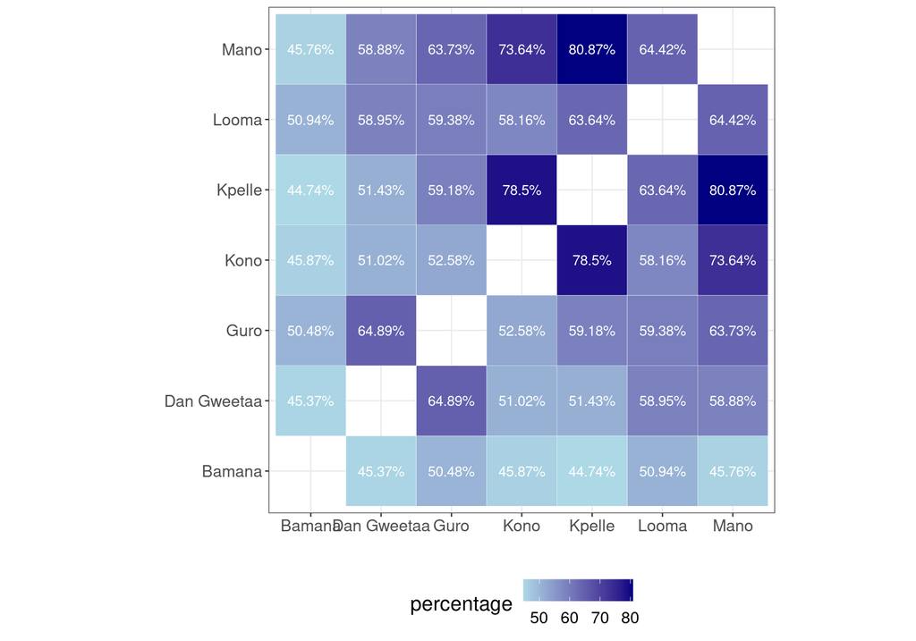

```r
df_pairwise_total |>
  left_join(df_pairwise_within_construction) |>
  mutate(percentage = round(n/total*100, 2),
         item1 = case_match(item1,
                            "Dan_Gweetaa" ~ "Dan Gweetaa",
                            .default = item1),
         item2 = case_match(item2,
                            "Dan_Gweetaa" ~ "Dan Gweetaa",
                            .default = item2)) |>
  select(item1, item2, percentage) |>
  ggplot(aes(item1, item2))+
  geom_tile(aes(fill = percentage), colour = "white") +
  geom_text(aes(label = str_c(percentage, "%")), colour = "white") +
  scale_fill_gradient(low = "lightblue", high = "navy")+
  coord_fixed()+
  labs(x = "", y = "") +
  theme(legend.position = "bottom")
```

Теперь можем провести быструю кластеризацию:

**hclust**

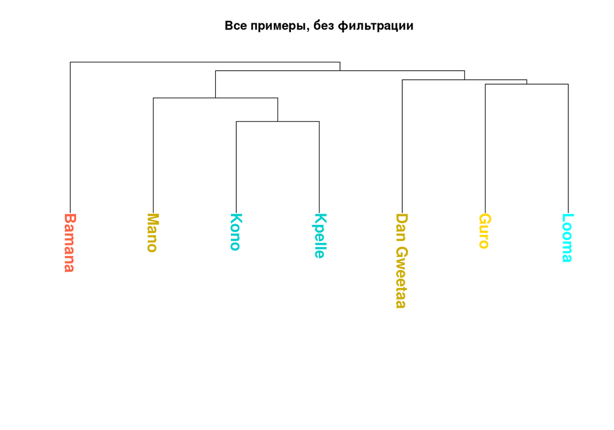

```r
df_wide |>
  mutate(across(Guro:Bamana, function(x){ifelse(is.na(x), 0, 1)})) |>
  select(Guro:Bamana) |>
  t() |>
  dist(method = "binary")  ->
  all_stimuli

all_stimuli |>
  hclust() |>
  as.phylo() %>%
  plot(main = "Все примеры, без фильтрации",
       tip.color = colors$color[match(.$tip.label, colors$language)],
       direction = "downwards",
       cex = 1.5,
       font = 2)
```

**neighbornet**

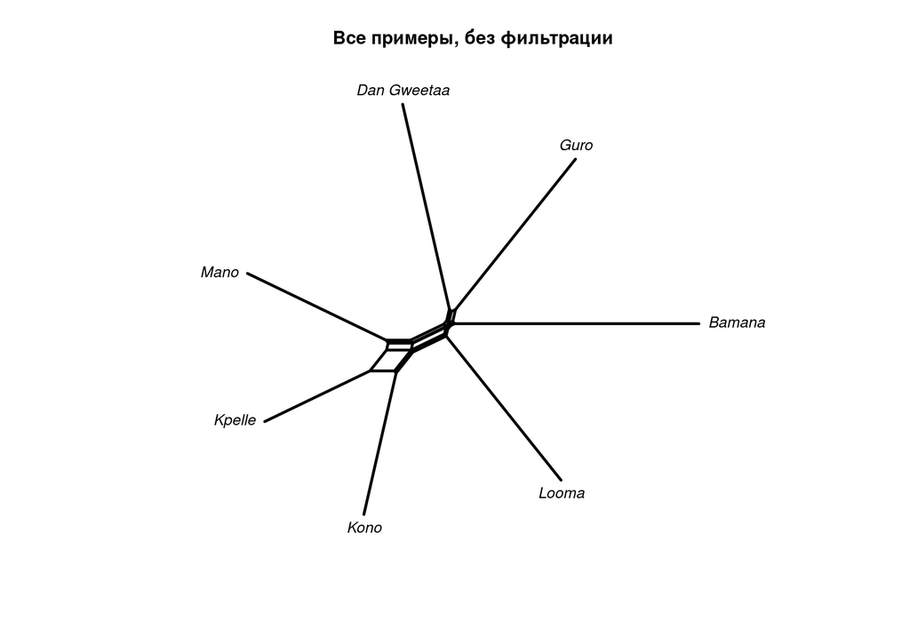

```r
all_stimuli |>
  neighborNet() |>
  plot()
title(main = "Все примеры, без фильтрации")
```

Можно еще посмотреть на кластеризацию конструкций, но это не поместиться на экран. Однако я считаю, что это было бы интересно Сереже.

Вот что будет, если взять только первые строки для каждого языка:

**hclust**

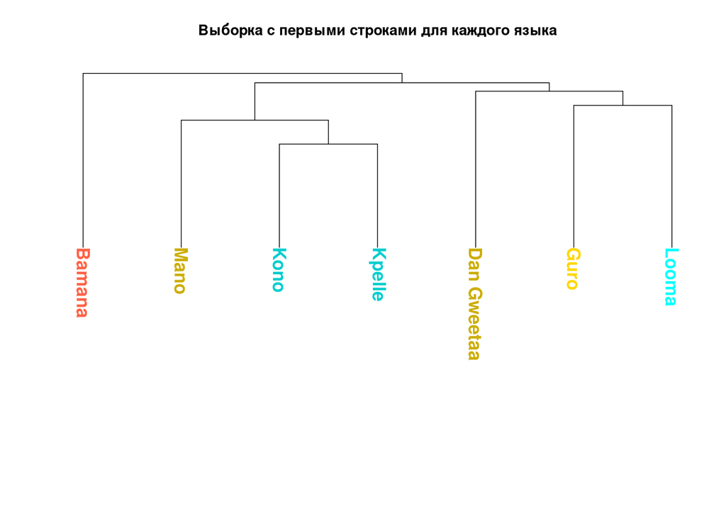

```r
df |>
  filter(!str_detect(construction, "no equivalent"),
         !is.na(construction_type)) |>
  group_by(number, language) |>
  slice(1)  |>
  ungroup() |>
  select(number, language, construction_type) |>
  mutate(construction_type2 = 1) |>
  pivot_wider(names_from = language, values_from = construction_type2, values_fill = 0) |>
  select(Bamana:Mano)  |>
  t() |>
  dist(method = "binary")  ->
  sample_first_construction

sample_first_construction |>
  hclust() |>
  as.phylo() %>%
  plot(main = "Выборка с первыми строками для каждого языка",
       tip.color = colors$color[match(.$tip.label, colors$language)],
       direction = "downwards",
       cex = 1.5,
       font = 2)
```

**neighbornet**

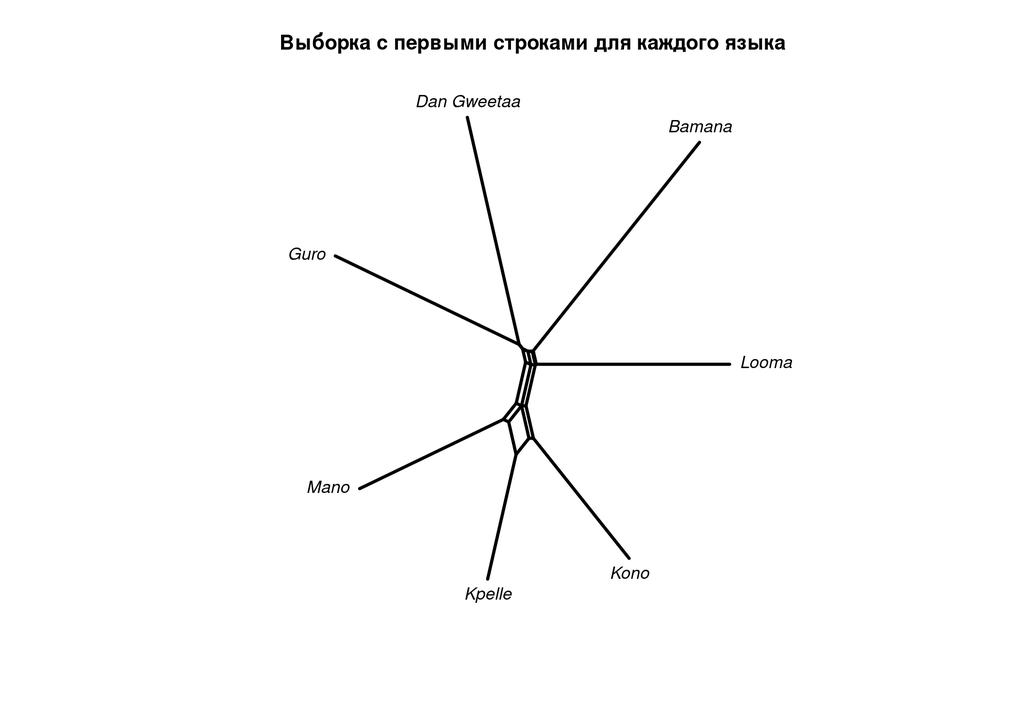

```r
sample_first_construction |>
  neighborNet() |>
  plot()
title(main = "Выборка с первыми строками для каждого языка")
```

> МХ: А что будет, если выбрать случайный эквивалент, а не первую строку?

Вот что будет, если взять случайный эквивалент для каждого языка `set.seed(42)` (такие же 3, 5, 7, 12, 13, 15; похож на 4, 8, 11):

**hclust**

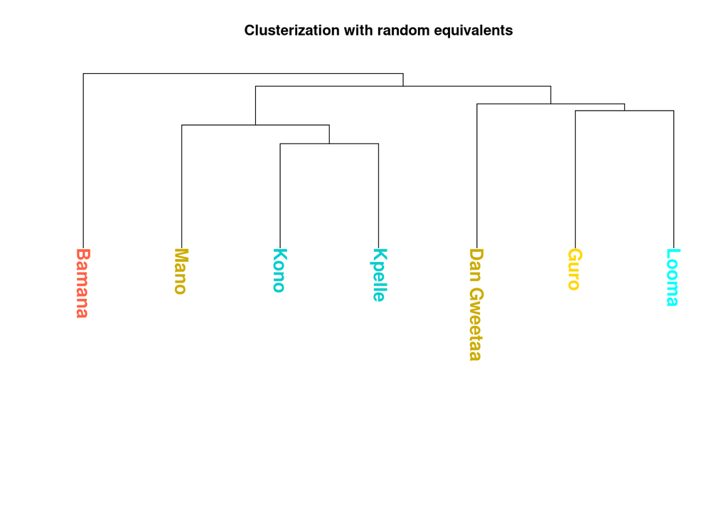

```r
set.seed(42)
df |>
  filter(!str_detect(construction, "no equivalent"),
         !is.na(construction_type)) |>
  group_by(number, language) |>
  slice_sample(n = 1) |>
  ungroup() |>
  select(number, language, construction_type) |>
  mutate(construction_type2 = 1) |>
  pivot_wider(names_from = language, values_from = construction_type2, values_fill = 0) |>
  select(Bamana:Mano)  |>
  t() |>
  dist(method = "binary")  ->
  sample_random_construction

sample_random_construction |>
  hclust() |>
  as.phylo() %>%
  plot(main = "Clusterization with random equivalents",
       tip.color = colors$color[match(.$tip.label, colors$language)],
       direction = "downwards",
       cex = 1.5,
       font = 2)
```

**neighbornet**

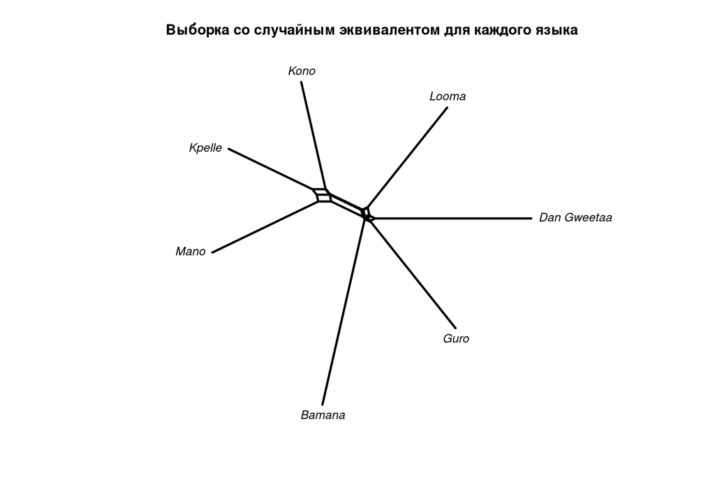

```r
sample_random_construction |>
  neighborNet() |>
  plot()
title(main = "Выборка со случайным эквивалентом для каждого языка")
```

Вот что будет, если взять случайный эквивалент для каждого языка `set.seed(57)` (такие же 1, 2, 6, 9, 10, 14):

**hclust**

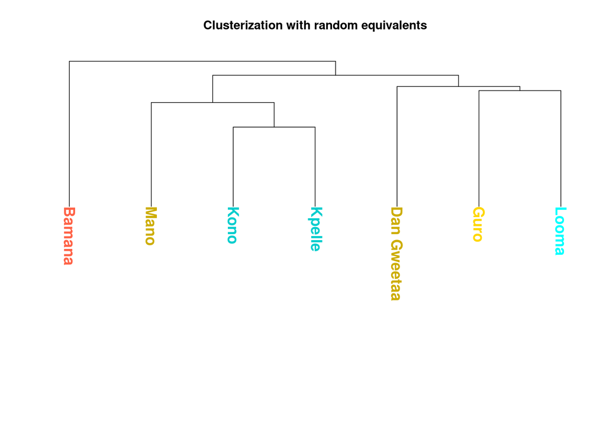

```r
set.seed(57)
df |>
  filter(!str_detect(construction, "no equivalent"),
         !is.na(construction_type)) |>
  group_by(number, language) |>
  slice_sample(n = 1) |>
  ungroup() |>
  select(number, language, construction_type) |>
  mutate(construction_type2 = 1) |>
  pivot_wider(names_from = language, values_from = construction_type2, values_fill = 0) |>
  select(Bamana:Mano)  |>
  t() |>
  dist(method = "binary")  ->
  sample_random_construction

sample_random_construction |>
  hclust() |>
  as.phylo() %>%
  plot(main = "Clusterization with random equivalents",
       tip.color = colors$color[match(.$tip.label, colors$language)],
       direction = "downwards",
       cex = 1.5,
       font = 2)
```

**neighbornet**

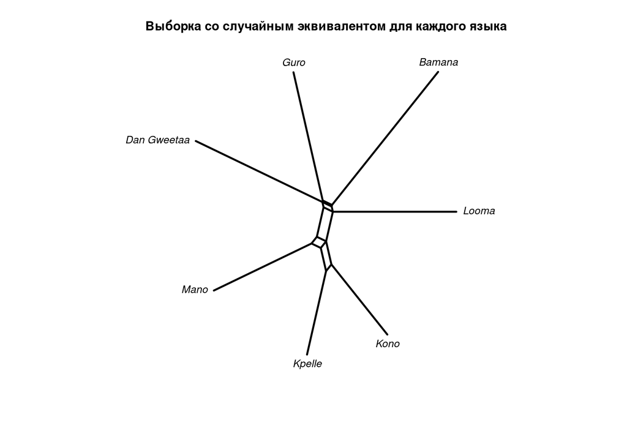

```r
sample_random_construction |>
  neighborNet() |>
  plot()
title(main = "Выборка со случайным эквивалентом для каждого языка")
```

Вот что будет, если взять только популярные конструкции:

**hclust**

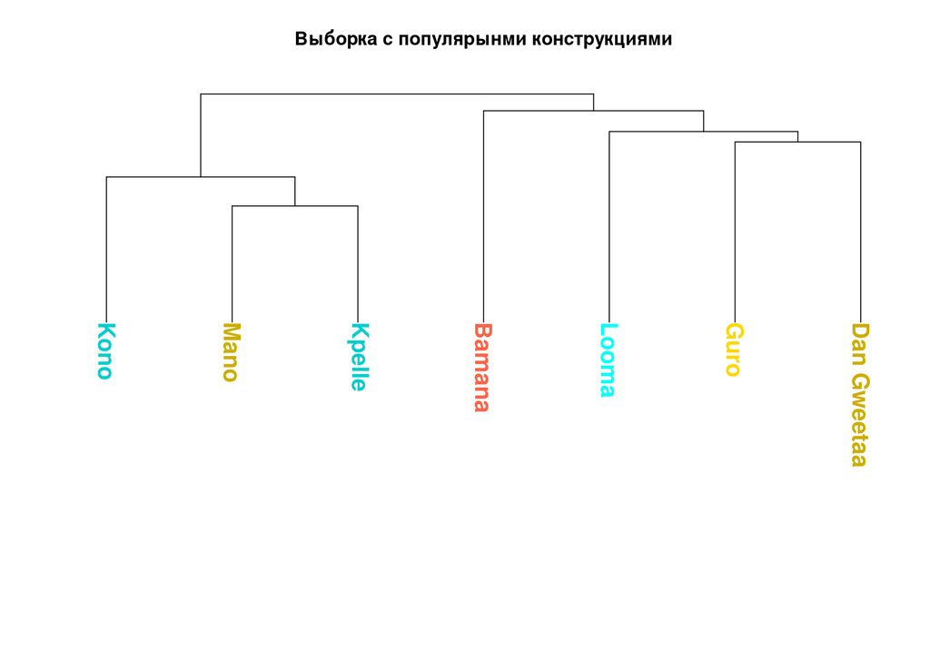

```r
df_wide |>
  group_by(number) |>
  filter(n == max(n))  |>
  ungroup() |>
  mutate(across(Guro:Bamana, function(x){ifelse(is.na(x), 0, 1)})) |>
  select(Guro:Bamana) |>
  t() |>
  dist(method = "binary")  ->
  sample_popular_construction

sample_popular_construction |>
  hclust() |>
  as.phylo() %>%
  plot(main = "Выборка с популярынми конструкциями",
       tip.color = colors$color[match(.$tip.label, colors$language)],
       direction = "downwards",
       cex = 1.5,
       font = 2)
```

**neighbornet**

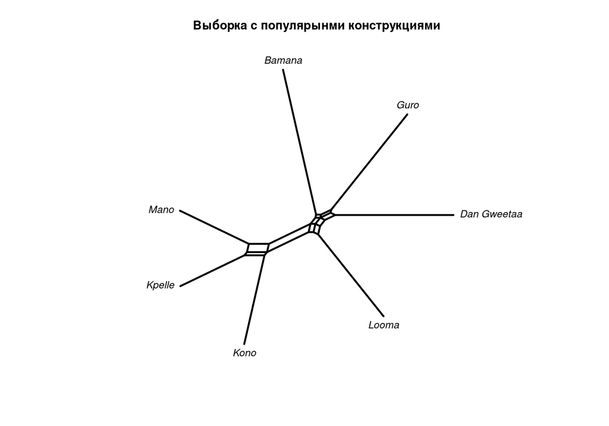

```r
sample_popular_construction  |>
  neighborNet() |>
  plot()
title(main = "Выборка с популярынми конструкциями")
```

> МХ: я также думаю что можно попробовать проанализировать только те стимулы где у ВСЕХ языков есть эквиваленты

```r
df |>
  count(number, language) |>
  count(number) |>
  filter(n == 7) |>
  pull(number) ->
  to_keep
to_keep
```

```
 [1]   1   2   3   4   6   7   8  11  12  14  16  17  18  19  22  23  25  26  27
[20]  28  29  31  32  33  34  35  36  38  39  40  41  43  44  46  49  50  51  53
[39]  55  57  58  60  63  66  67  68  69  70  71  72  74  75  76  77  78  79  80
[58]  81  83  85  89  90  91  93  94  96  98  99 100 101 102 105 106 108 109 110
[77] 117 118 119 121
```

Или наоборот, вот номера, для которых не во всех языках есть данные:

```r
df |>
  count(number, language) |>
  count(number) |>
  filter(n < 7) |>
  pull(number)
```

```
 [1]   5   9  10  13  15  20  21  24  30  37  42  45  47  48  52  54  56  59  61
[20]  62  64  65  73  82  84  86  87  88  92  95  97 103 104 107 111 113 115 116
[39] 120 123 124 126 127 129 130
```

Запустим кластеризацию:

**hclust**

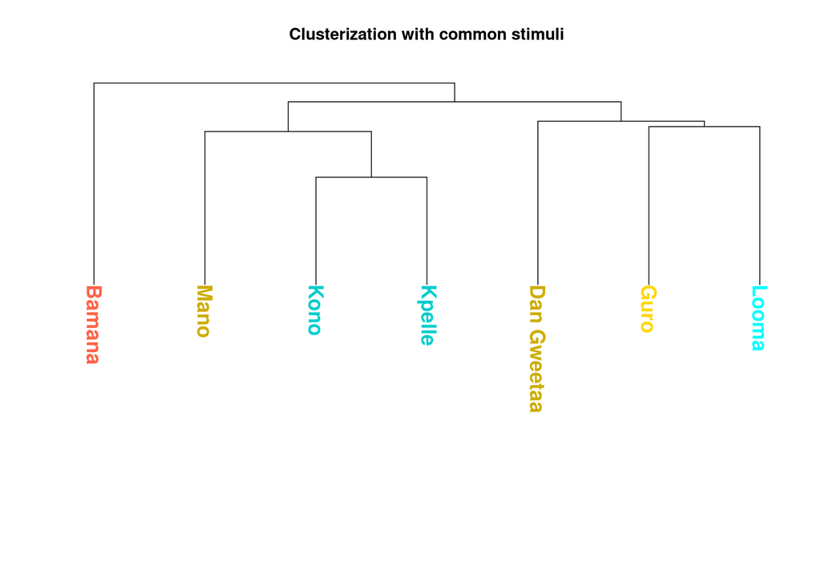

```r
df_wide |>
  filter(number %in% to_keep) |>
  mutate(across(Guro:Bamana, function(x){ifelse(is.na(x), 0, 1)}))  |>
  select(Guro:Bamana) |>
  t() |>
  dist(method = "binary") ->
  stimuli_sample_all_langs

stimuli_sample_all_langs |>
  hclust() |>
  as.phylo() %>%
  plot(main = "Clusterization with common stimuli",
       tip.color = colors$color[match(.$tip.label, colors$language)],
       direction = "downwards",
       cex = 1.5,
       font = 2)
```

**neighbornet**

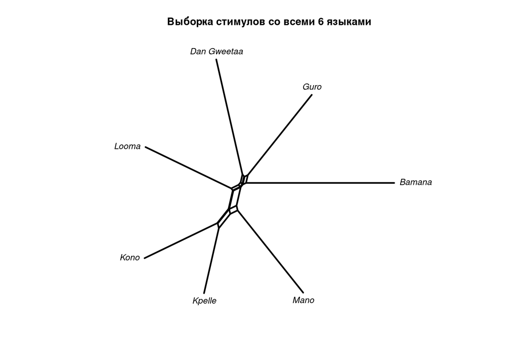

```r
stimuli_sample_all_langs  |>
  neighborNet() |>
  plot()
title(main = "Выборка стимулов со всеми 6 языками")
```

**heatmap**

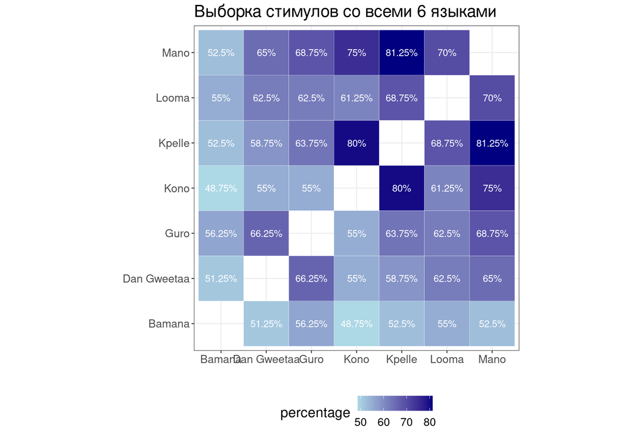

```r
df |>
  filter(number %in% to_keep,
         !str_detect(construction, "no equivalent"),
         !is.na(construction_type)) |>
  arrange(language)  |>
  distinct(language, number, construction_type)  |>
  pairwise_count(language, number) |>
  rename(total = n) ->
  df_pairwise_total

df |>
  filter(number %in% to_keep,
         !str_detect(construction, "no equivalent"),
         !is.na(construction_type)) |>
  group_by(number) |>
  arrange(language) |>
  pairwise_count(language, construction_type)  |>
  mutate(n = 1) |>
  group_by(item1, item2) |>
  reframe(n = sum(n)) ->
  df_pairwise_within_construction

df_pairwise_total |>
  left_join(df_pairwise_within_construction) |>
  mutate(percentage = round(n/total*100, 2),
         item1 = case_match(item1,
                            "Dan_Gweetaa" ~ "Dan Gweetaa",
                            .default = item1),
         item2 = case_match(item2,
                            "Dan_Gweetaa" ~ "Dan Gweetaa",
                            .default = item2)) |>
  select(item1, item2, percentage) |>
  ggplot(aes(item1, item2))+
  geom_tile(aes(fill = percentage), colour = "white") +
  geom_text(aes(label = str_c(percentage, "%")), colour = "white") +
  scale_fill_gradient(low = "lightblue", high = "navy")+
  coord_fixed()+
  labs(x = "", y = "", title = "Выборка стимулов со всеми 6 языками") +
  theme(legend.position = "bottom")
```

**hclust**

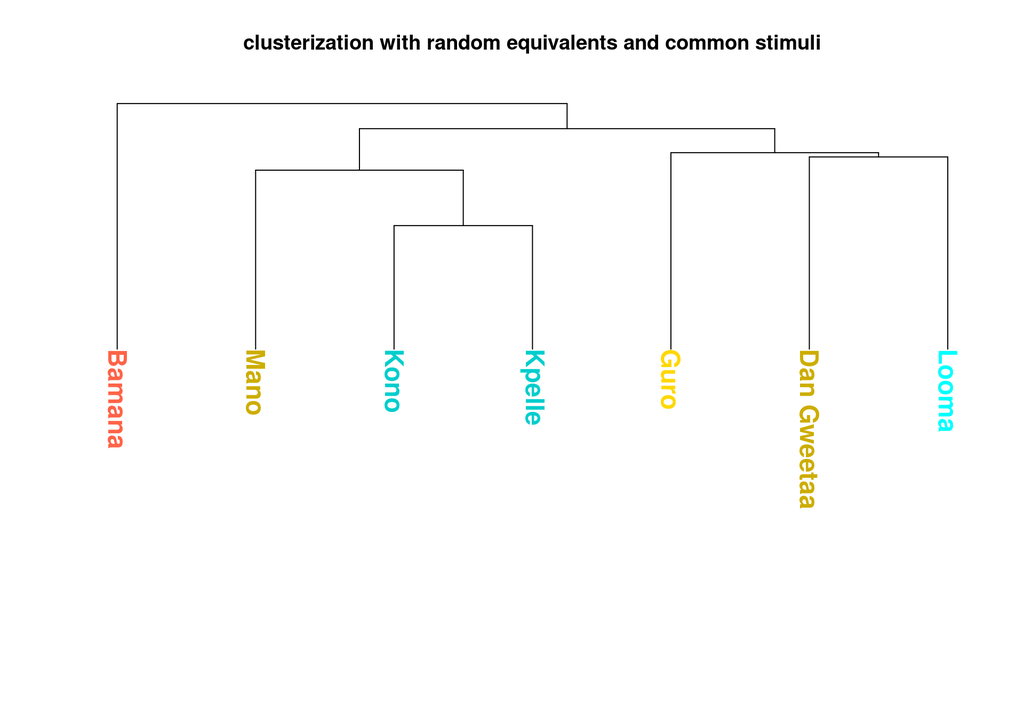

```r
df |>
  filter(!str_detect(construction, "no equivalent"),
         !is.na(construction_type),
         number %in% to_keep) |>
  group_by(number, language) |>
  slice_sample(n = 1) |>
  ungroup() |>
  select(number, language, construction_type) |>
  mutate(construction_type2 = 1) |>
  pivot_wider(names_from = language, values_from = construction_type2, values_fill = 0) |>
  select(Bamana:Mano)  |>
  t() |>
  dist(method = "binary") ->
  stimuli_sample_all_langs_and_random

stimuli_sample_all_langs_and_random |>
  hclust() |>
  as.phylo()  %>%
  plot(main = "clusterization with random equivalents and common stimuli",
       tip.color = colors$color[match(.$tip.label, colors$language)],
       direction = "downwards",
       cex = 1.5,
       font = 2)
```

**neighbornet**

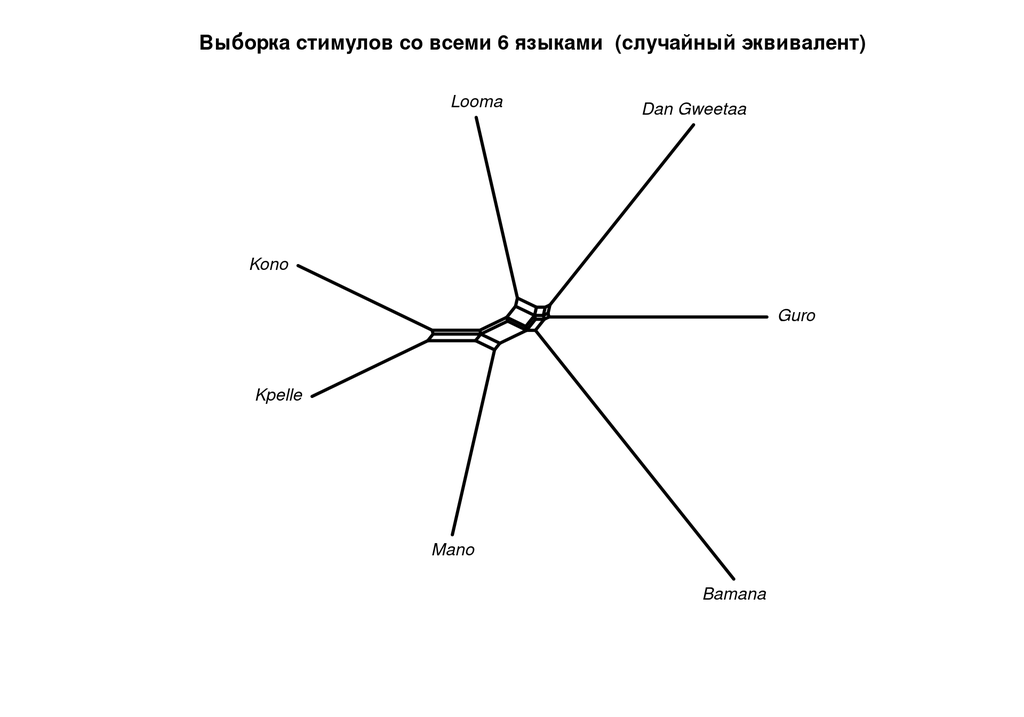

```r
stimuli_sample_all_langs_and_random  |>
  neighborNet() |>
  plot()
title(main = "Выборка стимулов со всеми 6 языками  (случайный эквивалент)")
```

**Группировка по языкам**

Перед тем, как приступить к перекодированию, которое предложила Маша К., посмотрим статистику конструкций по языкам:

```r
df |>
  count(language, construction_type) |>
  group_by(construction_type) |>
  mutate(overall = sum(n)) |>
  pivot_wider(names_from = language, values_from = n, values_fill = 0) |>
  arrange(desc(overall)) |>
  select(construction_type, overall, Guro, Dan_Gweetaa, Mano, Kpelle, Kono, Looma, Bamana)
```

| construction_type | overall | Guro | Dan_Gweetaa | Mano | Kpelle | Kono | Looma | Bamana |
| --- | --- | --- | --- | --- | --- | --- | --- | --- |
| X Aux Y V | 292 | 44 | 37 | 46 | 34 | 31 | 42 | 58 |
| X Aux V Y Ad | 175 | 23 | 22 | 35 | 21 | 20 | 20 | 34 |
| X Aux Y N V | 104 | 5 | 11 | 36 | 21 | 12 | 9 | 10 |
| X Aux N V Y Ad | 65 | 12 | 15 | 10 | 5 | 6 | 12 | 5 |
| X Aux V loc | 37 | 6 | 5 | 8 | 7 | 5 | 6 | 0 |
| Xgen N Aux V Y Ad | 35 | 8 | 3 | 13 | 5 | 1 | 4 | 1 |
| X Aux Xrefl N V Y Ad | 32 | 4 | 2 | 11 | 7 | 5 | 0 | 3 |
| Y be X Ad | 19 | 2 | 1 | 4 | 4 | 4 | 2 | 2 |
| Ygen N be X Ad | 18 | 0 | 2 | 4 | 5 | 4 | 2 | 1 |
| Xgen N be Y Ad | 16 | 1 | 1 | 5 | 3 | 2 | 3 | 1 |
| Y Aux V X Ad | 16 | 3 | 2 | 2 | 1 | 2 | 2 | 4 |
| X be Y Ad | 15 | 1 | 1 | 2 | 3 | 4 | 1 | 3 |
| Ygen N Aux V X Ad | 13 | 0 | 2 | 7 | 3 | 1 | 0 | 0 |
| X+Y Aux N V | 12 | 0 | 0 | 5 | 5 | 2 | 0 | 0 |
| Ygen N Aux X V | 10 | 0 | 7 | 1 | 1 | 1 | 0 | 0 |
| X+Y Aux V | 9 | 1 | 0 | 0 | 3 | 1 | 1 | 3 |
| X Aux Xrefl V Y Ad | 8 | 1 | 1 | 2 | 1 | 1 | 1 | 1 |
| X Aux N V | 8 | 0 | 1 | 2 | 2 | 2 | 1 | 0 |
| Y Aux X N V | 7 | 1 | 2 | 2 | 2 | 0 | 0 | 0 |
| Y Aux X V | 6 | 0 | 1 | 0 | 0 | 0 | 0 | 5 |
| X Aux Z V Y Ad | 5 | 3 | 0 | 1 | 0 | 0 | 0 | 1 |
| Xgen Y Aux V | 4 | 1 | 1 | 1 | 0 | 0 | 1 | 0 |
| X+Y be N Ad | 3 | 0 | 0 | 0 | 1 | 1 | 0 | 1 |
| X Aux 3sg V Y Ad | 3 | 1 | 1 | 1 | 0 | 0 | 0 | 0 |
| Ygen N be.neg X Ad | 3 | 0 | 0 | 1 | 1 | 1 | 0 | 0 |
| X+Y Aux V X+Yrefl Ad | 3 | 0 | 0 | 3 | 0 | 0 | 0 | 0 |
| X Aux V Y N Ad | 2 | 0 | 0 | 0 | 0 | 0 | 0 | 2 |
| X V Aux Y Ad | 2 | 0 | 0 | 0 | 0 | 0 | 0 | 2 |
| X be X Ad | 2 | 0 | 0 | 0 | 0 | 0 | 0 | 2 |
| X be Y N Ad | 2 | 0 | 1 | 0 | 0 | 0 | 0 | 1 |

[output cut: 58 more lines]

Маша предложила классификацию, которую я попробую воспроизвести.

> 1. простая переходная вида X Aux Y V (только этот случай)
> 2. простая непереходная X Aux V Y Ad, X Aux V loc, X+Y Aux V, Y Aux V X Ad (по идее исчерпывающий список, а что я забыла?)
> 3. конструкция с копулой - можно взять автоматически все случаи, где в формуле есть копула be: Y be X Ad, X be Y Ad, X be adj Y Ad, N be Xgen Y Ad, X+Y be N Ad и т.д.
> 4. некопульная конструкция со сложным глаголом - взять автоматически все случаи, где в формуле выполняется два условия: есть Aux (=нет be) и есть хотя бы одно N (вместе переходные, и непереходные) - X Aux N V Y Ad; X Aux Y N V; Xgen N Aux V Y Ad и т.д.

> По идее это не исчерпывающий список, останется что-то на периферии вроде X+Y Aux V X+Ypron recp Ad, но это редкие штуки.

```r
df |>
  count(language, construction_type) |>
  mutate(type = case_when(construction_type == "X Aux Y V" ~ "transitive",
                          str_detect(construction_type, "Aux") &
                            !str_detect(construction_type, "N") ~ "intransitive",
                          str_detect(construction_type, "be") ~ "copula",
                          str_detect(construction_type, "Aux") &
                            str_detect(construction_type, "N") ~ "complex verb",
                          TRUE ~ "other")) |>
  group_by(construction_type) |>
  mutate(overall = sum(n)) |>
  pivot_wider(names_from = language, values_from = n, values_fill = 0) |>
  arrange(desc(overall)) |>
  select(construction_type, type,   overall, Guro, Dan_Gweetaa, Mano, Kpelle, Kono, Looma, Bamana)
```

| construction_type | type | overall | Guro | Dan_Gweetaa | Mano | Kpelle | Kono | Looma | Bamana |
| --- | --- | --- | --- | --- | --- | --- | --- | --- | --- |
| X Aux Y V | transitive | 292 | 44 | 37 | 46 | 34 | 31 | 42 | 58 |
| X Aux V Y Ad | intransitive | 175 | 23 | 22 | 35 | 21 | 20 | 20 | 34 |
| X Aux Y N V | complex verb | 104 | 5 | 11 | 36 | 21 | 12 | 9 | 10 |
| X Aux N V Y Ad | complex verb | 65 | 12 | 15 | 10 | 5 | 6 | 12 | 5 |
| X Aux V loc | intransitive | 37 | 6 | 5 | 8 | 7 | 5 | 6 | 0 |
| Xgen N Aux V Y Ad | complex verb | 35 | 8 | 3 | 13 | 5 | 1 | 4 | 1 |
| X Aux Xrefl N V Y Ad | complex verb | 32 | 4 | 2 | 11 | 7 | 5 | 0 | 3 |
| Y be X Ad | copula | 19 | 2 | 1 | 4 | 4 | 4 | 2 | 2 |
| Ygen N be X Ad | copula | 18 | 0 | 2 | 4 | 5 | 4 | 2 | 1 |
| Xgen N be Y Ad | copula | 16 | 1 | 1 | 5 | 3 | 2 | 3 | 1 |
| Y Aux V X Ad | intransitive | 16 | 3 | 2 | 2 | 1 | 2 | 2 | 4 |
| X be Y Ad | copula | 15 | 1 | 1 | 2 | 3 | 4 | 1 | 3 |
| Ygen N Aux V X Ad | complex verb | 13 | 0 | 2 | 7 | 3 | 1 | 0 | 0 |
| X+Y Aux N V | complex verb | 12 | 0 | 0 | 5 | 5 | 2 | 0 | 0 |
| Ygen N Aux X V | complex verb | 10 | 0 | 7 | 1 | 1 | 1 | 0 | 0 |
| X+Y Aux V | intransitive | 9 | 1 | 0 | 0 | 3 | 1 | 1 | 3 |
| X Aux Xrefl V Y Ad | intransitive | 8 | 1 | 1 | 2 | 1 | 1 | 1 | 1 |
| X Aux N V | complex verb | 8 | 0 | 1 | 2 | 2 | 2 | 1 | 0 |
| Y Aux X N V | complex verb | 7 | 1 | 2 | 2 | 2 | 0 | 0 | 0 |
| Y Aux X V | intransitive | 6 | 0 | 1 | 0 | 0 | 0 | 0 | 5 |
| X Aux Z V Y Ad | intransitive | 5 | 3 | 0 | 1 | 0 | 0 | 0 | 1 |
| Xgen Y Aux V | intransitive | 4 | 1 | 1 | 1 | 0 | 0 | 1 | 0 |
| X+Y be N Ad | copula | 3 | 0 | 0 | 0 | 1 | 1 | 0 | 1 |
| X Aux 3sg V Y Ad | intransitive | 3 | 1 | 1 | 1 | 0 | 0 | 0 | 0 |
| Ygen N be.neg X Ad | copula | 3 | 0 | 0 | 1 | 1 | 1 | 0 | 0 |
| X+Y Aux V X+Yrefl Ad | intransitive | 3 | 0 | 0 | 3 | 0 | 0 | 0 | 0 |
| X Aux V Y N Ad | complex verb | 2 | 0 | 0 | 0 | 0 | 0 | 0 | 2 |
| X V Aux Y Ad | intransitive | 2 | 0 | 0 | 0 | 0 | 0 | 0 | 2 |
| X be X Ad | copula | 2 | 0 | 0 | 0 | 0 | 0 | 0 | 2 |
| X be Y N Ad | copula | 2 | 0 | 1 | 0 | 0 | 0 | 0 | 1 |

[output cut: 58 more lines]

Вот, что получилось. Маш, что исправить? Вот саммари:

```r
df |>
  mutate(type = case_when(construction_type == "X Aux Y V" ~ "transitive",
                          str_detect(construction_type, "Aux") &
                            !str_detect(construction_type, "N") ~ "intransitive",
                          str_detect(construction_type, "be") ~ "copula",
                          str_detect(construction_type, "Aux") &
                            str_detect(construction_type, "N") ~ "complex verb",
                          TRUE ~ "other")) |>
  count(type, language) |>
  pivot_wider(names_from = language, values_from = n, values_fill = 0)  |>
  arrange(-Looma) |>
  select(type, Guro, Dan_Gweetaa, Mano, Kpelle, Kono, Looma, Bamana)
```

| type | Guro | Dan_Gweetaa | Mano | Kpelle | Kono | Looma | Bamana |
| --- | --- | --- | --- | --- | --- | --- | --- |
| transitive | 44 | 37 | 46 | 34 | 31 | 42 | 58 |
| intransitive | 42 | 39 | 58 | 34 | 31 | 32 | 59 |
| complex verb | 33 | 49 | 89 | 53 | 32 | 31 | 27 |
| copula | 5 | 9 | 20 | 18 | 17 | 9 | 12 |
| other | 0 | 0 | 0 | 0 | 0 | 0 | 1 |

> Во-вторых, есть отдельная просьба про распределение конструкций и глаголов. В первом листе stimuli_general в столбце B есть семантическая разметка глаголов. Добавь её, пожалуйста, в глагольную таблицу, которую ты будешь снова генерировать. А дальше я бы попросила сделать следующее. Посчитать для каждого глагола, сколько ему в наших языках соответствует разных конструкций из 4 типов, выделенных выше. А потом слить глаголы из одной семантической группы и посчитать для семантических групп вместе статистику по конструкциям. Грубо говоря я хочу проверить, верно ли, что у глаголов вида effect будет больше переходных конструкций, а у feeling больше сложных глаголов, т.к. более абстрактные значения языки склонны выражать метафорически.

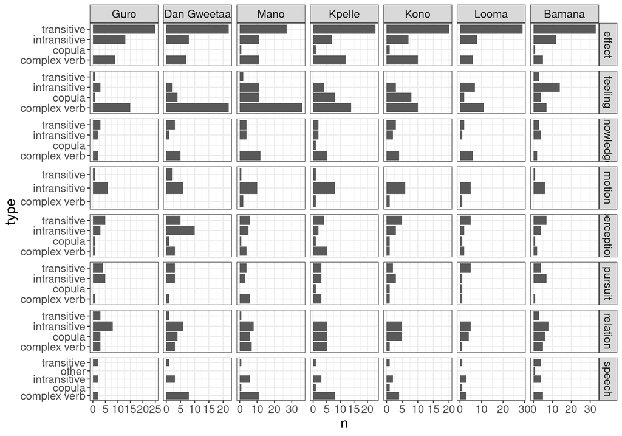

```r
df |>
  left_join(stimuli) |>
    mutate(type = case_when(construction_type == "X Aux Y V" ~ "transitive",
                          str_detect(construction_type, "Aux") &
                            !str_detect(construction_type, "N") ~ "intransitive",
                          str_detect(construction_type, "be") ~ "copula",
                          str_detect(construction_type, "Aux") &
                            str_detect(construction_type, "N") ~ "complex verb",
                          TRUE ~ "other")) |>
  count(type, language, semantic_type) |>
  mutate(language = str_replace(language, "_", " "),
         language = factor(language, levels = c("Guro", "Dan Gweetaa", "Mano", "Kpelle", "Kono", "Looma", "Bamana"))) |>
  ggplot(aes(n, type))+
  geom_col()+
  facet_grid(semantic_type~language, scales = "free")
```

Ну вот примерно, то, что ты имела в виду, наверное, но это все нужно пересчитать, после того, как мы утвердим тип каждой из конструкции.

**Адлоги**

Какие адлоги есть для каждого языка?

```r
df |>
  mutate(adposition = str_split(adposition, ", ")) |>
  unnest_longer(adposition) |>
  count(language, adposition) |>
  na.omit()
```

| language | adposition | n |
| --- | --- | --- |
| Bamana | bólo | 5 |
| Bamana | fɛ̀ | 7 |
| Bamana | kàn | 5 |
| Bamana | kɔ́ | 4 |
| Bamana | kɔ́nɔ | 1 |
| Bamana | kɔ́rɔ | 1 |
| Bamana | lá | 29 |
| Bamana | mà | 5 |
| Bamana | nɔ̀fɛ̀ | 2 |
| Bamana | yé | 6 |
| Bamana | ɲɛ́ | 1 |
| Dan_Gweetaa | bhàa | 2 |
| Dan_Gweetaa | bhȁ | 23 |
| Dan_Gweetaa | dhi̋ɤ | 3 |
| Dan_Gweetaa | dhɛ̏ | 2 |
| Dan_Gweetaa | gɔ̏ | 5 |
| Dan_Gweetaa | gɯ́ | 5 |
| Dan_Gweetaa | ká | 14 |
| Dan_Gweetaa | kèŋ̏ | 1 |
| Dan_Gweetaa | loc | 6 |
| Dan_Gweetaa | pi̋ɤ | 2 |
| Dan_Gweetaa | tȁ | 4 |
| Dan_Gweetaa | zɯ̏ | 1 |
| Guro | jì | 2 |
| Guro | la | 2 |
| Guro | leè | 3 |
| Guro | loc | 6 |
| Guro | lɛ | 8 |
| Guro | ta | 5 |
| Guro | và | 8 |
| Guro | ya̰ | 9 |
| Guro | zì | 2 |
| Guro | zuo | 2 |
| Guro | ɓa̰ | 22 |
| Kono | à | 10 |
| Kono | hù | 5 |
| Kono | lá | 1 |
| Kono | loc | 5 |
| Kono | mà | 27 |
| Kono | mɛ̌i | 1 |
| Kono | pòò | 1 |
| Kono | pɔ̀ | 4 |
| Kono | yêi | 4 |
| Kpelle | à | 12 |
| Kpelle | hù | 3 |
| Kpelle | lá | 1 |
| Kpelle | loc | 7 |
| Kpelle | púlû | 4 |
| Kpelle | pɔ́ | 3 |
| Kpelle | yêi | 4 |
| Kpelle | ɓà | 33 |
| Kpelle | ɲá | 1 |
| Looma | bà | 6 |
| Looma | bù | 1 |
| Looma | bɛ̀ | 5 |
| Looma | gà | 10 |
| Looma | kómá | 1 |
| Looma | loc | 6 |
| Looma | mà | 19 |
| Looma | pòlù | 2 |
| Looma | sù | 3 |
| Looma | tá | 2 |
| Looma | yà | 3 |
| Mano | bà | 5 |
| Mano | gé | 1 |
| Mano | gɛ̀nɛ̀ | 1 |
| Mano | ká | 23 |
| Mano | kɛ̀lɛ̀ | 6 |
| Mano | là | 7 |
| Mano | loc | 8 |
| Mano | lɛ̀ɛ̄ | 6 |
| Mano | mɔ̀ | 45 |
| Mano | píé | 7 |
| Mano | yí | 1 |
| Mano | ŋwɛ́ŋ̀ | 4 |

Какие были раньше проблемы:

- в коно нет адлогов
- в дан гвета есть адлоги dhi̋ɤ и dhiɤ̋, bhȁ и bhàa, которые, наверное, про одно и то же. Кроме того есть адлог loc.
- в гуро есть адлоги léè и leè, lɛ̄ и lɛ, ɓa̰ и ɓā̰. Кроме того есть адлог loc.
- в лома есть адлоги mà и mà̀ (с двумя знаками тона). Кроме того есть адлог loc.
- в мано есть адлоги píé и píé (я не понимаю в чем разница…).

Проблемы на 15.02.2023:

- В гуро ɓa̰ и ɓā̰ — разное?
- В гуро ya̰ и yā̰ — разное?

Я не совсем понял, что написала МХ, так что я пока посчитал вот такое вот. Какие адлоги из разных языков встречаются друг с другом в одной расширеной конструкции внутри одного стимула?

```r
df |>
  filter(!str_detect(construction, "no equivalent"),
         !is.na(construction_type),
         !is.na(adposition)) |>
  group_by(number) |>
  mutate(adposition = str_c(language, "__", adposition)) |>
  pairwise_count(adposition, construction_type)  |>
  group_by(item1, item2) |>
  reframe(n = sum(n)) |>
  arrange(desc(n))
```

| item1 | item2 | n |
| --- | --- | --- |
| Kpelle__ɓà | Mano__mɔ̀ | 22 |
| Mano__mɔ̀ | Kpelle__ɓà | 22 |
| Kono__mà | Kpelle__ɓà | 16 |
| Kpelle__ɓà | Kono__mà | 16 |
| Kono__mà | Mano__mɔ̀ | 15 |
| Mano__mɔ̀ | Kono__mà | 15 |
| Kono__à | Kpelle__à | 10 |
| Kpelle__à | Kono__à | 10 |
| Dan_Gweetaa__bhȁ | Kpelle__ɓà | 7 |
| Dan_Gweetaa__bhȁ | Mano__mɔ̀ | 7 |
| Kpelle__à | Mano__ká | 7 |
| Kpelle__ɓà | Dan_Gweetaa__bhȁ | 7 |
| Mano__ká | Kpelle__à | 7 |
| Mano__mɔ̀ | Dan_Gweetaa__bhȁ | 7 |
| Guro__ɓa̰ | Kpelle__ɓà | 6 |
| Kono__à | Mano__ká | 6 |
| Kpelle__ɓà | Guro__ɓa̰ | 6 |
| Mano__ká | Kono__à | 6 |
| Bamana__lá | Kpelle__ɓà | 5 |
| Bamana__lá | Mano__mɔ̀ | 5 |
| Dan_Gweetaa__loc | Guro__loc | 5 |
| Dan_Gweetaa__loc | Kono__loc | 5 |
| Dan_Gweetaa__loc | Kpelle__loc | 5 |
| Dan_Gweetaa__loc | Looma__loc | 5 |
| Dan_Gweetaa__loc | Mano__loc | 5 |
| Guro__loc | Dan_Gweetaa__loc | 5 |
| Guro__loc | Kono__loc | 5 |
| Guro__loc | Kpelle__loc | 5 |
| Guro__loc | Looma__loc | 5 |
| Guro__loc | Mano__loc | 5 |

[output cut: 634 more lines]

Я попробовал сделать таблицу, но она получается огромная… Возьмем только примеры, где больше одного:

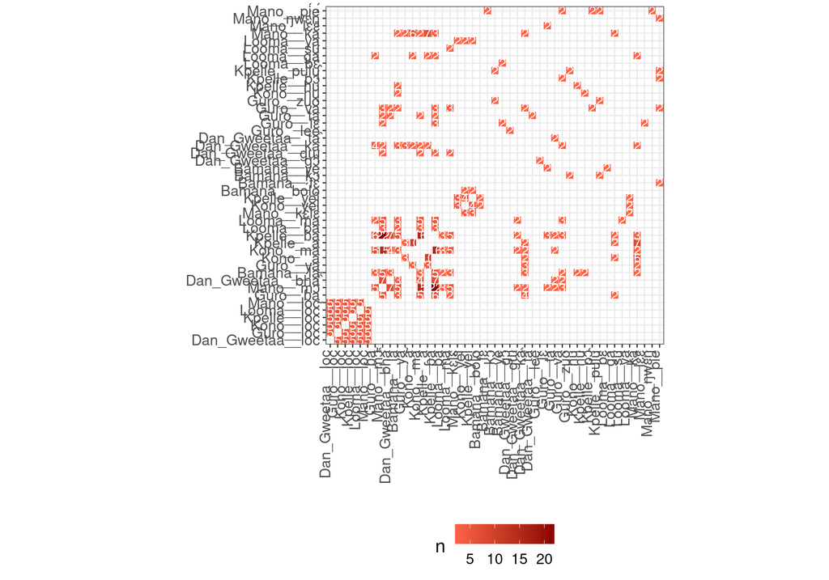

```r
df |>
  filter(!str_detect(construction, "no equivalent"),
         !is.na(construction_type),
         !is.na(adposition)) |>
  group_by(number) |>
  mutate(adposition = str_c(language, "__", adposition)) |>
  pairwise_count(adposition, construction_type) |>
  group_by(item1, item2) |>
  reframe(n = sum(n)) |>
  filter(n > 1) |>
  mutate(item1 = fct_reorder(item1, n, .desc = TRUE),
         item2 = fct_reorder(item2, n, .desc = TRUE)) |>
  ggplot(aes(item1, item2))+
  geom_tile(aes(fill = n), colour = "white") +
  geom_text(aes(label = n), colour = "white") +
  scale_fill_gradient(low = "tomato", high = "darkred")+
  coord_fixed()+
  labs(x = "", y = "") +
  theme(legend.position = "bottom",
        axis.text.x = element_text(angle = 90, vjust = 0, hjust=1))
```

Вот так я понял Машину идеи про то, как посмотреть соответствия между языками, берите лупу:

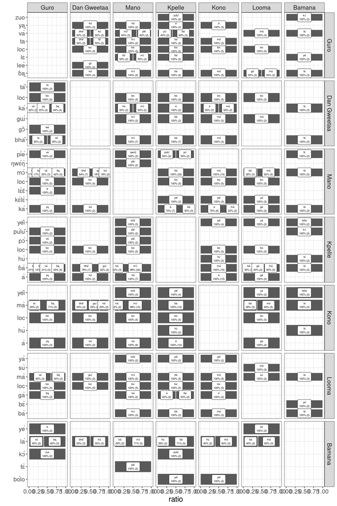

```r
df |>
  filter(!str_detect(construction, "no equivalent"),
         !is.na(construction_type),
         !is.na(adposition)) |>
  group_by(number) |>
  mutate(adposition = str_c(language, "__", adposition)) |>
  pairwise_count(adposition, construction_type) |>
  group_by(item1, item2) |>
  reframe(n = sum(n)) |>
  filter(n > 1) |>
  separate(item1, into = c("language1", "adposition1"), sep = "__") |>
  separate(item2, into = c("language2", "adposition2"), sep = "__") |>
  group_by(language1, language2, adposition1) |>
  reframe(ratio = n/sum(n),
            n = n,
            adposition2 = adposition2) |>
  distinct() |>
  mutate(language1 = str_replace(language1, "_", " "),
         language1 = factor(language1, levels = c("Guro", "Dan Gweetaa", "Mano", "Kpelle", "Kono", "Looma", "Bamana")),
         language2 = str_replace(language2, "_", " "),
         language2 = factor(language2, levels = c("Guro", "Dan Gweetaa", "Mano", "Kpelle", "Kono", "Looma", "Bamana"))) |>
  ggplot(aes(ratio, adposition1, label = str_c(adposition2, "\n",
                                               round(ratio*100), "% (",
                                               n, ")")))+
  geom_col(color = "white")+
  geom_label(position = position_stack(vjust = .5), size = 2)+
  facet_grid(language1~language2, scales = "free")+
  labs(y = "")
```

**Глагольная этимология**

Все этимологии:

**hclust**

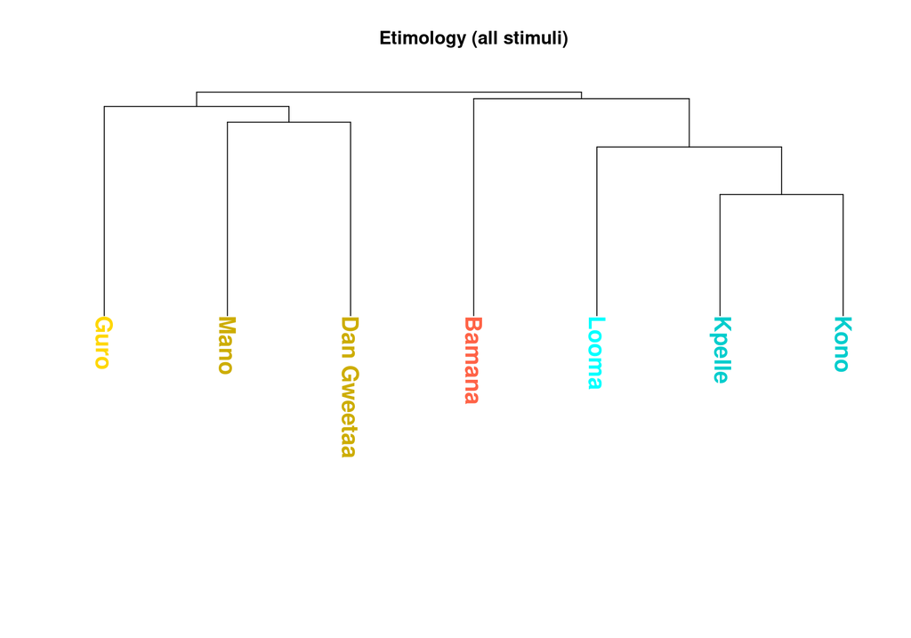

```r
et <- readxl::read_xlsx("../GM_merged_wide_verb_VV2.xlsx")
et |>
  select(number, predicate_eng, stimuli, ends_with("etym")) |>
  pivot_longer(names_to = "source",
               values_to = "value",
               ends_with("etym")) |>
  na.omit() |>
  filter(value != "0") |>
  distinct() |>
  mutate(value = str_replace_all(value, "able, be", "able||| be"),
         value = str_replace_all(value, "bear, give", "bear||| give"),
         value = str_replace_all(value, ", shut", "||| shut"),
         value = str_replace_all(value, "cry, weep", "cry||| weep"),
         value = str_replace_all(value, "shoot, sting", "shoot||| sting"),
         value = str_replace_all(value, "stuck, get", "stuck||| get"),
         value = str_replace_all(value, ",", ";"),
         value = str_replace_all(value, "\\|\\|\\|", ","),
         value = str_split(value, ";")) |>
  unnest_longer(value) |>
  distinct() |>
  mutate(value2 = 1) |>
  pivot_wider(names_from = source, values_from = value2, values_fill = 0) |>
  select(ends_with("etym")) |>
  rename(Guro = Guro_etym,
         Looma = Looma_etym,
         Mano = Mano_etym,
         Kono = Kono_etym,
         Dan_Gweetaa = Dan_etym,
         Bamana = Bamana_etym,
         Kpelle = Kpelle_etym) |>
  t() |>
  dist(method = "binary") ->
  etym

etym |>
  hclust() |>
  as.phylo()  %>%
  plot(main = "Etimology (all stimuli)",
       tip.color = colors$color[match(.$tip.label, colors$language)],
       direction = "downwards",
       cex = 1.5,
       font = 2)
```

**neighbornet**

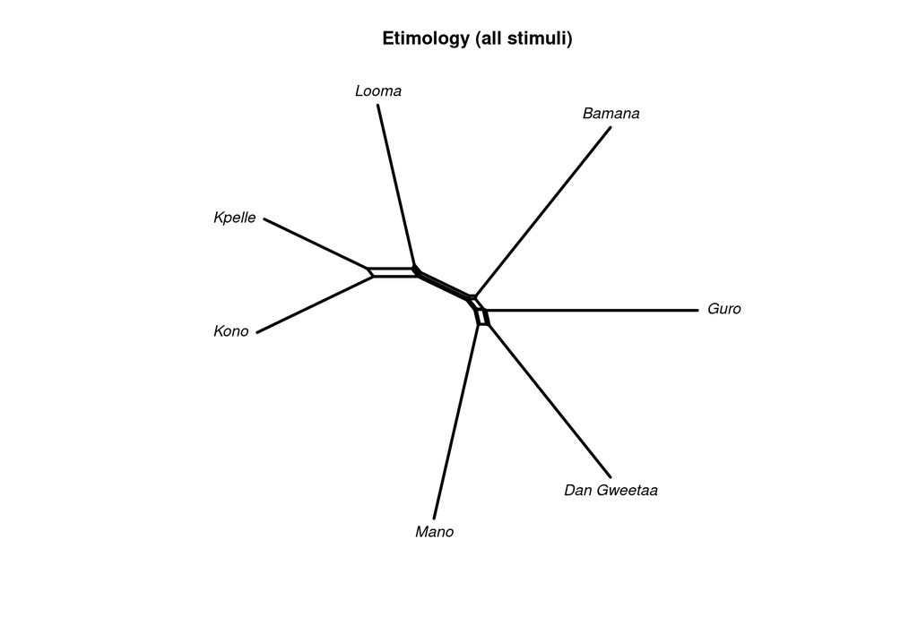

```r
etym  |>
  neighborNet() |>
  plot()
title(main = "Etimology (all stimuli)")
```

Кластеризация со случайным эквивалентом. Я запустил более 10 раз – ничего в структуре не поменялось, только длина ножек менялась.

**hclust**

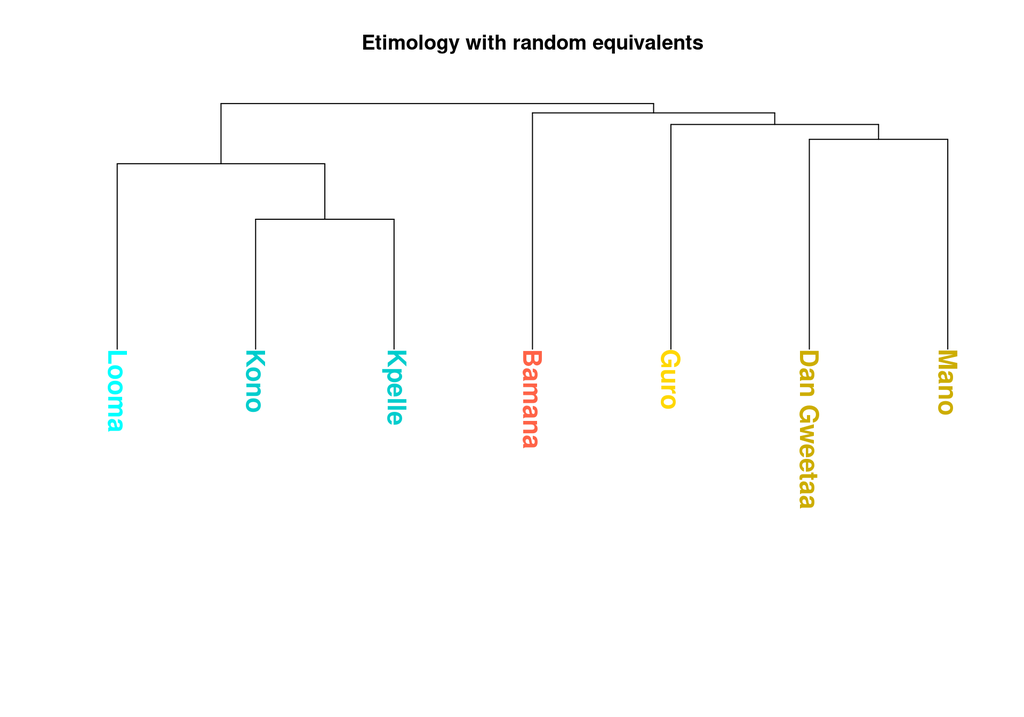

```r
et |>
  select(number, predicate_eng, stimuli, ends_with("etym")) |>
  pivot_longer(names_to = "source",
               values_to = "value",
               ends_with("etym")) |>
  na.omit() |>
  filter(value != "0") |>
  distinct() |>
  mutate(value = str_replace_all(value, "able, be", "able||| be"),
         value = str_replace_all(value, "bear, give", "bear||| give"),
         value = str_replace_all(value, ", shut", "||| shut"),
         value = str_replace_all(value, "cry, weep", "cry||| weep"),
         value = str_replace_all(value, "shoot, sting", "shoot||| sting"),
         value = str_replace_all(value, "stuck, get", "stuck||| get"),
         value = str_replace_all(value, ",", ";"),
         value = str_replace_all(value, "\\|\\|\\|", ","),
         value = str_split(value, ";")) |>
  unnest_longer(value) |>
  distinct() |>
  mutate(value2 = 1) |>
  group_by(number, source) |>
  sample_n(size = 1) |>
  ungroup() |>
  mutate(value2 = 1) |>
  pivot_wider(names_from = source, values_from = value2, values_fill = 0) |>
  select(ends_with("etym")) |>
  rename(Guro = Guro_etym,
         Looma = Looma_etym,
         Kono = Kono_etym,
         Mano = Mano_etym,
         Dan_Gweetaa = Dan_etym,
         Bamana = Bamana_etym,
         Kpelle = Kpelle_etym) |>
  t() |>
  dist(method = "binary") ->
  etym_random

etym_random |>
  hclust() |>
  as.phylo()  %>%
  plot(main = "Etimology with random equivalents",
       tip.color = colors$color[match(.$tip.label, colors$language)],
       direction = "downwards",
       cex = 1.5,
       font = 2)
```

**neighbornet**

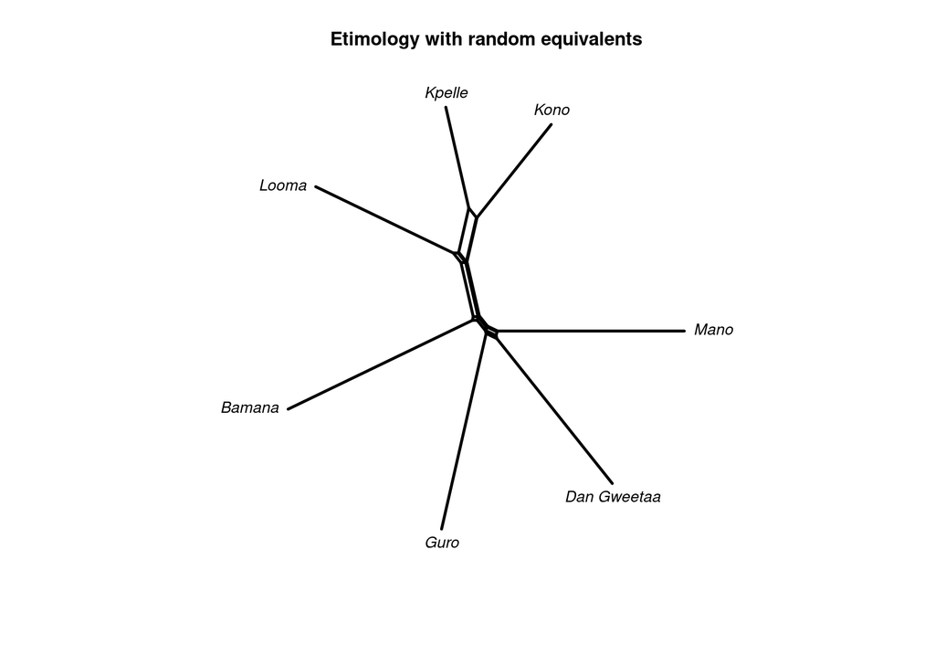

```r
etym_random  |>
  neighborNet() |>
  plot()
title(main = "Etimology with random equivalents")
```

Это сделано по следующей таблице:

```r
et |>
  select(number, predicate_eng, ends_with("etym")) |>
  pivot_longer(names_to = "source",
               values_to = "value",
               ends_with("etym")) |>
  na.omit() |>
  filter(value != "0") |>
  distinct() |>
  mutate(value = str_replace_all(value, "able, be", "able||| be"),
         value = str_replace_all(value, "bear, give", "bear||| give"),
         value = str_replace_all(value, ", shut", "||| shut"),
         value = str_replace_all(value, "cry, weep", "cry||| weep"),
         value = str_replace_all(value, "shoot, sting", "shoot||| sting"),
         value = str_replace_all(value, "stuck, get", "stuck||| get"),
         value = str_replace_all(value, ",", ";"),
         value = str_replace_all(value, "\\|\\|\\|", ","),
         value = str_split(value, ";")) |>
  unnest_longer(value) |>
  distinct() |>
  mutate(value2 = value) |>
  pivot_wider(names_from = source, values_from = value2) |>
  arrange(number, predicate_eng, value) |>
  select(-value)
```

| number | predicate_eng | Guro_etym | Looma_etym | Mano_etym | Dan_etym | Bamana_etym | Kpelle_etym | Kono_etym |
| --- | --- | --- | --- | --- | --- | --- | --- | --- |
| 1 | hurt | NA | NA | NA | break (to)-2-wi | NA | NA | NA |
| 1 | hurt | NA | NA | NA | do-1-ke | NA | NA | NA |
| 1 | hurt | NA | NA | NA | go out (to)-bo | NA | NA | NA |
| 1 | hurt | NA | hurt-xona | NA | NA | NA | hurt-xona | hurt-xona |
| 1 | hurt | illness-1-jankaro | NA | NA | NA | NA | NA | NA |
| 1 | hurt | NA | NA | NA | NA | pain-1-dimi | NA | NA |
| 1 | hurt | NA | NA | sufferance-4-waa | NA | NA | NA | NA |
| 1 | hurt | NA | NA | NA | turn-pene | NA | NA | NA |
| 2 | be sick with | NA | NA | NA | NA | catch-2-miita | NA | NA |
| 2 | be sick with | NA | NA | NA | do-1-ke | NA | NA | NA |
| 3 | be afraid of | NA | NA | NA | NA | NA | 0fear-nyow | 0fear-nyow |
| 3 | be afraid of | NA | NA | NA | fear-1-g’ila | fear-1-g’ila | NA | NA |
| 3 | be afraid of | NA | fear-3-duwa | fear-3-duwa | NA | NA | NA | NA |
| 4 | throw | throw-1 (to)-fili | throw-1 (to)-fili | NA | NA | throw-1 (to)-fili | throw-1 (to)-fili | throw-1 (to)-fili |
| 4 | throw | NA | NA | throw-2 (to)-zu | throw-2 (to)-zu | NA | NA | NA |
| 5 | be sufficient to | NA | NA | NA | catch-3-catch | NA | NA | NA |
| 5 | be sufficient to | NA | NA | NA | NA | go out (to)-bo | NA | NA |
| 6 | be like sb | go out (to)-bo | NA | go out (to)-bo | go out (to)-bo | go out (to)-bo | NA | NA |
| 6 | be like sb | NA | knock down-kula | NA | NA | NA | knock down-kula | knock down-kula |
| 7 | have trust | NA | NA | confidence-dannaya | NA | NA | NA | NA |
| 7 | have trust | NA | NA | NA | go out (to)-bo | NA | NA | NA |
| 7 | have trust | NA | lie down-1-d’a | NA | NA | lie down-1-d’a | lie down-1-d’a | lie down-1-d’a |
| 7 | have trust | send-2-bo | NA | NA | NA | NA | NA | NA |
| 7 | have trust | NA | NA | stand (to)-1-d’o | stand (to)-1-d’o | NA | stand (to)-1-d’o | NA |
| 8 | take | take-2-si | NA | take-2-si | take-2-si | NA | NA | NA |
| 8 | take | NA | NA | NA | NA | take-3-ta | NA | NA |
| 8 | take | NA | take-5-sige | NA | NA | NA | take-5-sige | take-5-sige |
| 9 | see what | NA | NA | look-2 (to)-ga | NA | NA | NA | NA |
| 9 | see what | NA | NA | NA | see (to)-1-ye | see (to)-1-ye | NA | NA |
| 9 | see what | NA | see (to)-3-ka | NA | NA | NA | NA | NA |

[output cut: 476 more lines]

**Preprocessing**

```r
library(tidyverse)
mano_kpelle_pre <- readxl::read_xlsx("../say_stimuli.xlsx", sheet = "mano + kpelle")

mano_kpelle_pre |>
  rename(number = Number,
         construction = `Mano construction`,
         construction_type = `Mano extended construction type`,
         adposition = `Mano Postposition`,
         verb = `Mano verb`,
         verb_meaning = `Mano Complex verb meaning`) |>
  mutate(language = "Mano") |>
  select(number, construction, construction_type, adposition, verb, verb_meaning, language) |>
  filter(!is.na(construction)) ->
  mano

mano_kpelle_pre |>
  rename(number = Number,
         construction = `Kpelle construction`,
         construction_type = `Kpelle extended construction type`,
         adposition = `Kpelle postposition`,
         verb = `Kpelle verb`,
         verb_meaning = `Kpelle complex verb meaning`) |>
  mutate(language = "Kpelle") |>
  select(number, construction, construction_type, adposition, verb, verb_meaning, language) |>
  filter(!is.na(construction)) ->
  kpelle

rm(mano_kpelle_pre)

kono_pre <- readxl::read_xlsx("../say_stimuli.xlsx", sheet = "kono")

kono_pre |>
  rename(number = Number,
         construction = `Kono construction...8`,
         construction_type = `Kono extended construction`,
         adposition = `Kono adposition`,
         verb = `Kono verb`,
         verb_meaning = `Kono complex verb`) |>
  mutate(language = "Kono") |>
  select(number, construction, construction_type, adposition, verb, verb_meaning, language) |>
  filter(!is.na(construction)) ->
  kono

rm(kono_pre)

# I renamed one of the columns to "Looma extended construction"
looma_pre <- readxl::read_xlsx("../say_stimuli.xlsx", sheet = "Looma")

looma_pre |>
  rename(number = Number,
         construction = `Looma construction`,
         construction_type = `Looma extended construction`,
         adposition = `Looma Postposition`,
         verb = `Looma Verb`,
         verb_meaning = `Looma Complex Verb`) |>
  mutate(language = "Looma") |>
  select(number, construction, construction_type, adposition, verb, verb_meaning, language) |>
  filter(!is.na(construction)) ->
  looma

rm(looma_pre)

# I renamed one of the columns to "Guro extended construction"
guro_pre <- readxl::read_xlsx("../say_stimuli.xlsx", sheet = "Guro")

guro_pre |>
  rename(number = Number,
         construction = `Guro construction`,
         construction_type = `Guro extended construction`,
         adposition = `Guro Postposition`,
         verb = `Guro Verb`,
         verb_meaning = `Guro Complex Verb`) |>
  mutate(language = "Guro") |>
  select(number, construction, construction_type, adposition, verb, verb_meaning, language) |>
  filter(!is.na(construction)) ->
  guro

rm(guro_pre)

dan_pre <- readxl::read_xlsx("../say_stimuli.xlsx", sheet = "Dan Gweetaa from Vydrin")

dan_pre |>
  rename(number = Number,
         construction = `Dan construction`,
         construction_type = `Dan extended construction type`,
         adposition = `Dan Postposition`,
         verb = `Dan Verb`,
         verb_meaning = `Dan complex verb meaning`) |>
  mutate(language = "Dan_Gweetaa") |>
  select(number, construction, construction_type, adposition, verb, verb_meaning, language) |>
  filter(!is.na(construction)) ->
  dan

rm(dan_pre)

bamana_pre <- readxl::read_xlsx("../say_stimuli.xlsx", sheet = "Bambara Vydrin")
bamana_pre |>
  rename(number = Number,
         construction = `Bamana construction`,
         construction_type = `Bamana extended construction type`,
         adposition = `Bamana Postposition`,
         verb = `Bamana Verb`,
         verb_meaning = `Bamana complex verb meaning`) |>
  mutate(language = "Bamana") |>
  select(number, construction, construction_type, adposition, verb, verb_meaning, language) |>
  filter(!is.na(construction)) ->
  bamana

guro |>
  bind_rows(kono, kpelle, looma, mano, dan, bamana) |>
  write_csv("../GM_merged.csv", na = "")

readxl::read_xlsx("../say_stimuli.xlsx", sheet = "stimuli_general") |>
  select(Number, `English predicate`, `Stimulus sentence (SAY)`, `Semantic types`) |>
  rename(number = Number,
         predicate_eng = `English predicate`,
         stimuli = `Stimulus sentence (SAY)`,
         semantic_type = `Semantic types`) ->
  stimuli

read_csv("../GM_merged.csv") |>
  filter(!str_detect(construction, "no equivalent"),
         !is.na(construction_type)) |>
  group_by(number) |>
  add_count(construction_type) |>
  arrange(number, desc(n)) |>
  select(-adposition) |>
  group_by(number, construction_type, language, n) |>
  reframe(construction = str_c(construction, collapse = "; ")) |>
  pivot_wider(names_from = language, values_from = construction, values_fill = "") |>
  group_by(number) |>
  mutate(id = 1:n()) |>
  ungroup() |>
  left_join(stimuli) |>
  select(number, semantic_type, predicate_eng, stimuli, id, n, construction_type, Guro, Looma, Mano, Dan_Gweetaa, Kono, Kpelle, Bamana, Kono) |>
  writexl::write_xlsx("../GM_merged_wide.xlsx")

read_csv("../GM_merged.csv") |>
  filter(!str_detect(construction, "no equivalent"),
         !is.na(construction_type)) |>
  select(-construction) |>
  distinct(number, construction_type, language, adposition) |>
  group_by(number, construction_type, language) |>
  reframe(adposition = str_c(adposition, collapse = "; ")) |>
  pivot_wider(names_from = language, values_from = adposition, values_fill = "") |>
  group_by(number) |>
  mutate(id = 1:n()) |>
  ungroup() |>
  left_join(stimuli) |>
  select(number, semantic_type, predicate_eng, stimuli, id, construction_type, Guro, Looma, Mano, Dan_Gweetaa, Kono, Kpelle, Bamana, Kono) |>
  writexl::write_xlsx("../GM_merged_wide_adpositions.xlsx")

read_csv("../GM_merged.csv") |>
  filter(!str_detect(construction, "no equivalent"),
         !is.na(construction_type)) |>
  select(-construction) |>
  distinct(number, construction_type, language, verb) |>
  group_by(number, construction_type, language) |>
  reframe(verb = str_c(verb, collapse = "; ")) |>
  pivot_wider(names_from = language, values_from = verb, values_fill = "") |>
  group_by(number) |>
  mutate(id = 1:n()) |>
  ungroup() |>
  left_join(stimuli) |>
  select(number, predicate_eng, stimuli, id, construction_type, Guro, Looma, Mano, Dan_Gweetaa, Kpelle, Bamana, Kono) |>
  writexl::write_xlsx("../GM_merged_wide_verb.xlsx")

read_csv("../GM_merged.csv") |>
  filter(!str_detect(construction, "no equivalent"),
         !is.na(construction_type),
         !is.na(verb_meaning)) |>
  select(-construction) |>
  distinct(number, construction_type, language, verb, verb_meaning) |>
  mutate(verb_meaning = str_c(verb_meaning, " (", verb, ")")) |>
  group_by(number, construction_type, language) |>
  reframe(verb_meaning = str_c(verb_meaning, collapse = "; ")) |>
  pivot_wider(names_from = language, values_from = verb_meaning, values_fill = "") |>
  group_by(number) |>
  mutate(id = 1:n()) |>
  ungroup() |>
  left_join(stimuli) |>
  select(number, predicate_eng, stimuli, id, construction_type, Guro, Looma, Mano, Dan_Gweetaa, Kpelle, Bamana, Kono) |>
  writexl::write_xlsx("../GM_merged_wide_verb_meaning.xlsx")
```